# mock_interview_python

### Mock Interview Python Screening test

```python
import pandas as pd
import matplotlib as mpl
import matplotlib.pyplot as plt
dataframe = pd.read_csv("adult_census_data.csv")
```

**Q1. After importing the adult_census_data.csv file, please filter this to include only the following criteria:**

State-Gov

Bachelors

Never-Married

Adm-Clerical

Not-in-familiy

White

Male

United States

<=50K

**Feel free to any method to complete this tasks. However, we recommend you use either list filtering [], or .loc to complete this task.**

**Put your code below**

```python
filtered_df = dataframe.loc[
    (dataframe[' State-gov'] == ' State-gov') &
    (dataframe[' Bachelors'] == ' Bachelors') &
    (dataframe[' Never-married'] == ' Never-married') &
    (dataframe[' Adm-clerical'] == ' Adm-clerical') &
    (dataframe[' Not-in-family'] == ' Not-in-family') &
    (dataframe[' White'] == ' White') &
    (dataframe[' Male'] == ' Male') &
    (dataframe[' United-States'] == ' United-States') &
    (dataframe[' <=50K'] == ' <=50K')
]
```

**Currently, the dataframe you are using has the following column names:**

[' State-gov', ' Bachelors', ' Never-married', ' Adm-clerical', ' Not-in-family', ' White', ' Male', ' United-States', ' <=50K'] **Q2. Please re-name all the newly filtered columns in the pandas DataFrame to the following:**

Employment Type, Degree Status, Marriage-Status, Job-Role, Family-Role, Ethnicity, Gender, Country, Earnings

E.g. State-Gov becomes Employment Type, Bachelors becomes Degree Status, etc.

**Put your code below**

```python
filtered_df = filtered_df.rename(columns={
    ' State-gov':'Employment Type',
    ' Bachelors':'Degree Status',
    ' Never-married':'Marriage-Status',
    ' Adm-clerical':'Job-Role',
    ' Not-in-family':'Family-Role',
    ' White':'Ethnicity',
    ' Male':'Gender',
    ' United-States':'Country',
    ' <=50K':'Earnings'
})
```

**Q3. The Job Role Columns holds the job information for each individual in this census snapshot. Using this column, create a Bar Chart that shows the count of 'Unique' Jobs per Job Group in the "Job-Role" Column in ascending order, as per the provided image below**

**Put your code below**

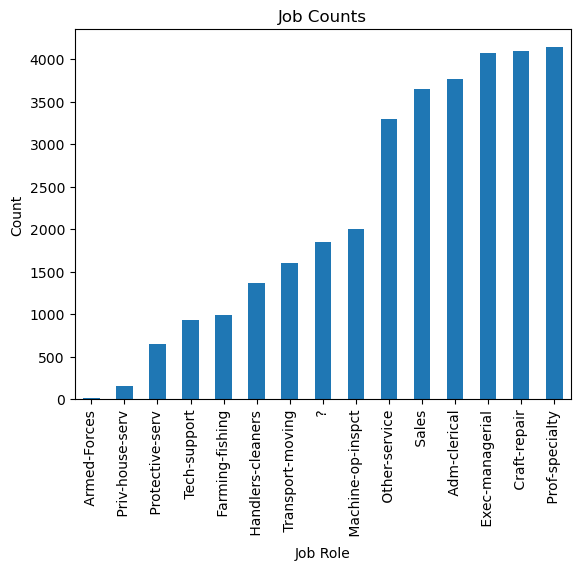

```python
job_counts = dataframe[' Adm-clerical'].value_counts().sort_values()

job_counts.plot(kind='bar')

plt.title('Job Counts')
plt.xlabel('Job Role')
plt.ylabel('Count')
plt.show()
```

**Q4. Please create two bar plots as per below that show:**

```
1) The number of individuals who have a High School Graduate Diploma AND earn <=50K in the United States
2) The number of individuals who have a High School Graduate Diploma AND earn >50K in the United States
```

Please note you will be looking specifically at the *Job Role* column

**Put Your Code Below**

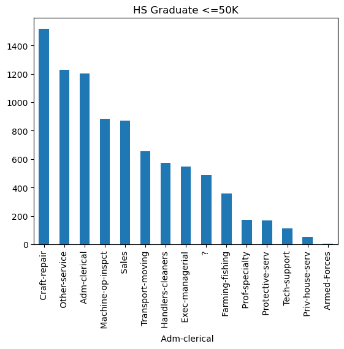

```python
hs_low = dataframe[
    (dataframe[' Bachelors'] == ' HS-grad') &
    (dataframe[' <=50K'] == ' <=50K')
]

hs_low[' Adm-clerical'].value_counts().plot(
    kind='bar'
)

plt.title('HS Graduate <=50K')
plt.show()
```

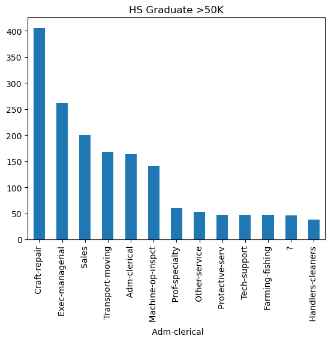

```python
hs_high = dataframe[
    (dataframe[' Bachelors'] == ' HS-grad') &
    (dataframe[' <=50K'] == ' >50K')
]

hs_high[' Adm-clerical'].value_counts().plot(
    kind='bar'
)

plt.title('HS Graduate >50K')
plt.show()
```

## Challenge Question

**Q5. Which Job Role has the highest *proportion* of individuals who earn >50K?**

**Put your code below**

```python
total = dataframe.groupby(
    ' Adm-clerical'
).size()
```

```python
high_income = dataframe[
    dataframe[' <=50K'] == '>50K'
].groupby(
    ' Adm-clerical'
).size()
```

```python
high_income = dataframe[
    dataframe[' <=50K'] == ' >50K'
].groupby(
    ' Adm-clerical'
).size()
```